# Finding groups: k-means and DBSCAN

## DBSCAN 2: grow a cluster, hop by hop

WhatI · k-meansII · DBSCANWrap-up

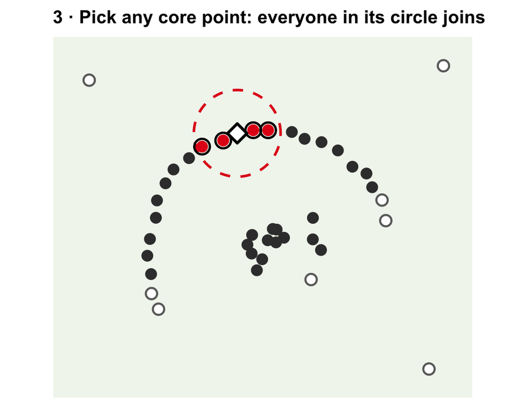

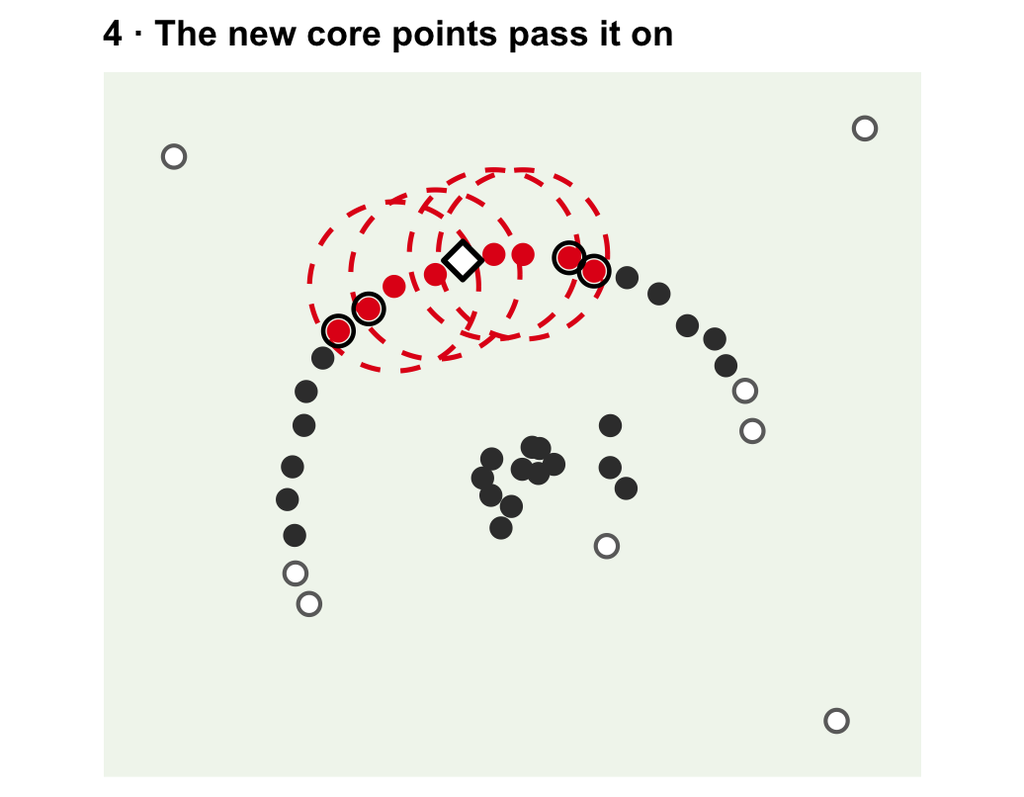

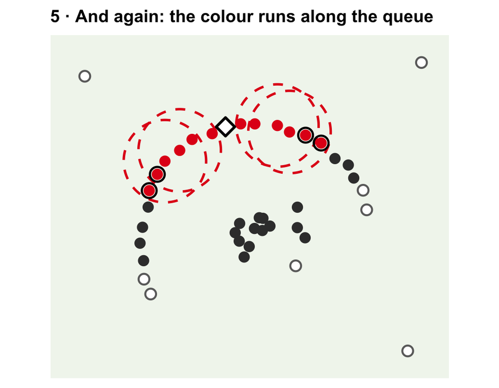

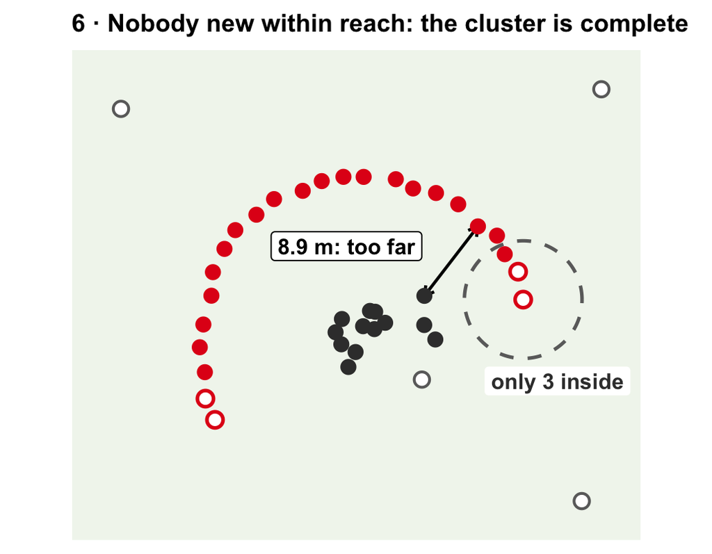

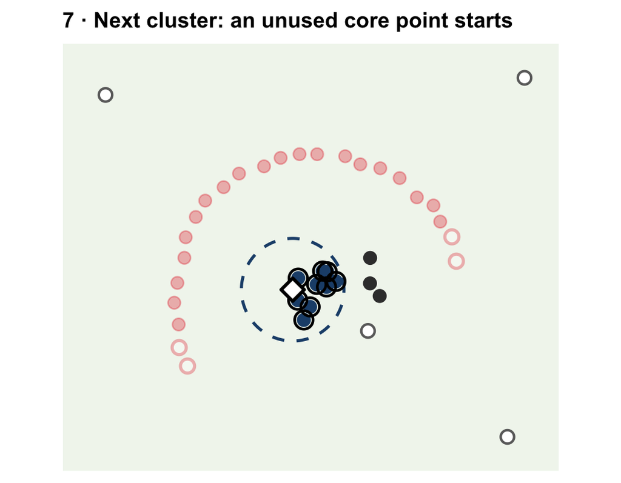

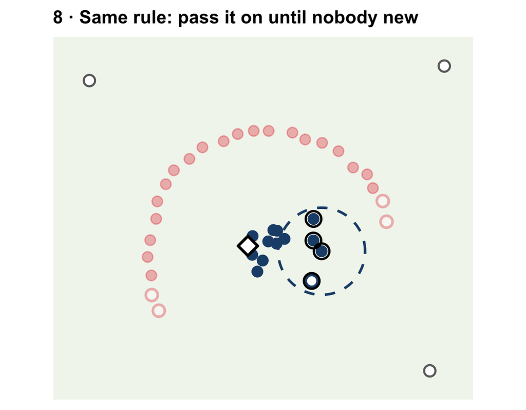

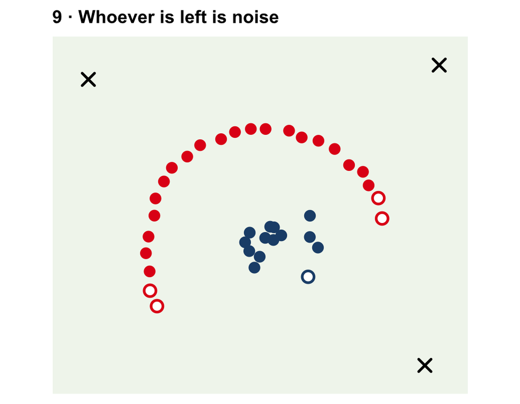

Starta core point diamond colours its circle

Pass it onnew **core** points colour their circles

Repeatthe colour follows the shape

Stopnobody new in reach. **Border** rings join, pass nothing on

Next clusteran unused core point starts, **same rule**

Noisenever reached: **cluster 0** in R crosses

The number of clusters is a result You never said “two”. You said what a crowd is, and two crowds were found.

## DBSCAN 3: now you choose eps and minPts

WhatI · k-meansII · DBSCANWrap-up

`eps`how far "near" reaches6 m

`minPts`how many make a crowd5

**1****Count.**

**2****Grow.**

Click **1** to count, **2** to grow, or ▶ play for both. Click a person to see why they are core, border or noise.

Speed

## Run DBSCAN on the map

WhatI · k-meansII · DBSCANWrap-up

**Notebook** lines 136–176 "Task 4: Basic DBSCAN" and the plot: given, ready to run*run together*

db_result <- dbscan(mca_coords[, 1:2], eps = 0.25, minPts = 5)

1. **From the `dbscan` package.** No seed: nothing here is random.
2. **The two coordinates** of the 36 answers.
3. **The radius**, in the units of the map’s axes.
4. **A crowd**: 5 answers inside the circle, the point itself included.

```
Clusters found: 4
```

```
Noise points: 5
```

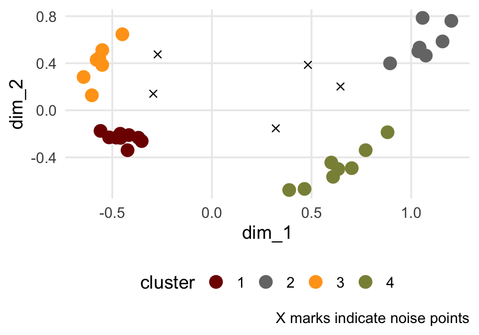

Cluster 0 is not a cluster `db_result$cluster` holds 0, 1, 2, 3, 4. The zeros are the noise points, drawn as ×.

## Class discussion: what is a noise point?

WhatI · k-meansII · DBSCANWrap-up

**Notebook** line 147 the discussion after Task 4*30 seconds with your neighbour*

DBSCAN reports 5 noise points on the map. What does that mean?

**A**Five rows contain errors and should be deleted from the data

**B**Five answers have too few close neighbours to belong to any crowd, with these settings

**C**Five answers were put in the smallest cluster

**D**Five answers that k-means would have put in the wrong cluster

**B.** A noise point is not a core point and is not within reach of one. It is a statement about **density**, and it depends on `eps` and `minPts`: change them and other points become noise. "Noise" is the algorithm's word. It does not mean the data are wrong.

## Your turn B: clusters, noise, and eps

Part II · lines 178–232 · in pairs

1. **Lines 180–186:** write code that lists the answers in each cluster, and the noise points.
2. **Line 188:** what is in each cluster? Which answers are hard to place?
3. **Lines 198–230:** the same chunk again with `eps = 0.5`. Run it, then try **0.1, 0.2, 0.3, 0.4**. Note clusters and noise each time.
4. **Line 196:** how does `eps` change the clusters? What happens to the noise? Should every point belong to a cluster? Which `eps` would you keep?

Syntax you need

```r
clustered_points |>          # made in lines 153–157
  arrange(cluster) |>
  print(n = Inf)

noise_points |>
  print(n = Inf)

# Task 5: change one number, rerun the whole chunk
db_result <- dbscan(mca_coords[, 1:2], eps = 0.5, minPts = 5)
```

- **Small `eps`**: small circles, few core points
- **Large `eps`**: big circles, crowds reach each other and merge
- Think of the field: what would a 1 m circle do? A 30 m circle?

**Stuck?**

- `clustered_points` not found: run lines 151–176 first
- The list did not change with `eps`: rerun the **whole** chunk, not only the first line

## Answers B: clusters and noise

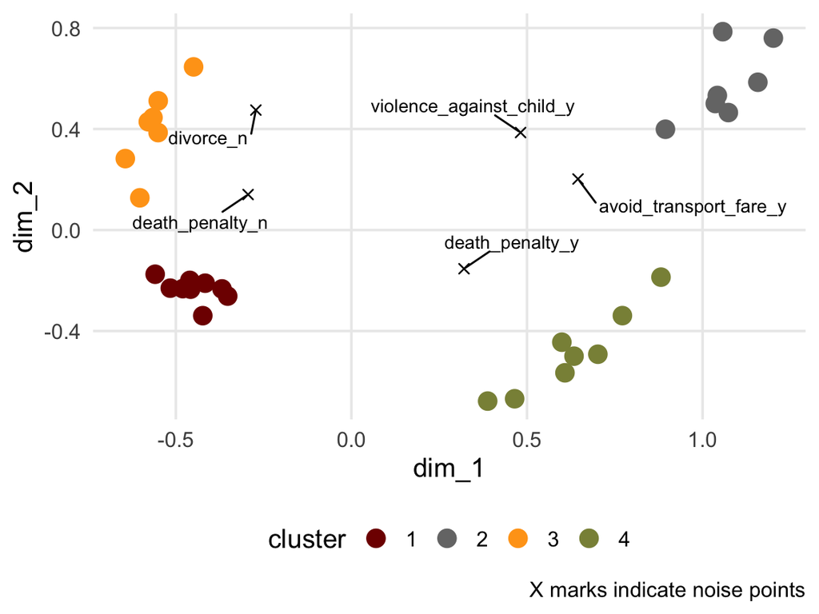

```r
clustered_points |> arrange(cluster) |>
  print(n = Inf)
noise_points |> print(n = Inf)
```

The same four groups As in Part I. Two methods with different ideas of a “group” agree: a reason to believe the groups.

Five answers left out Both death-penalty answers, `divorce_n`, fare dodging `_y`, violence against a child `_y`: between crowds, or at the thin edge of one.

What DBSCAN adds Clusters **and** the points that fit none. k-means hid these five inside its groups.

## Answers B: turning eps

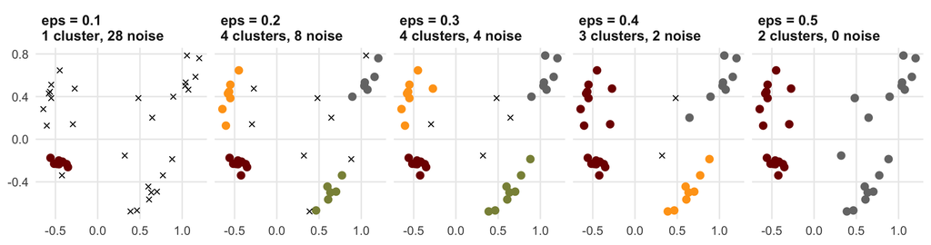

Small eps: almost all noise At 0.1 only the tight knot has 5 answers inside a circle: 1 cluster, 28 noise points.

Large eps: crowds merge Noise falls: 28, 8, 4, 2, 0. At 0.5 nothing is left out, and two clusters remain: every `_n` and every `_y`.

Keep 0.25 to 0.3 Four readable groups and a handful of noise points. Not every point has to belong: the leftovers are a finding too.

## How do you choose eps and minPts?

WhatI · k-meansII · DBSCANWrap-up

**Notebook** lines 190–232 "which eps is best?" · the plot is one extra line*concept*

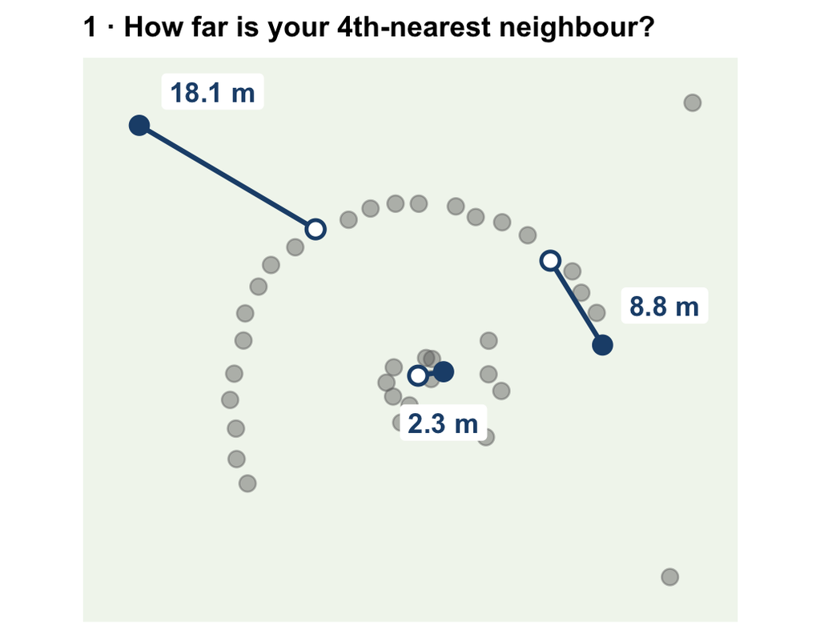

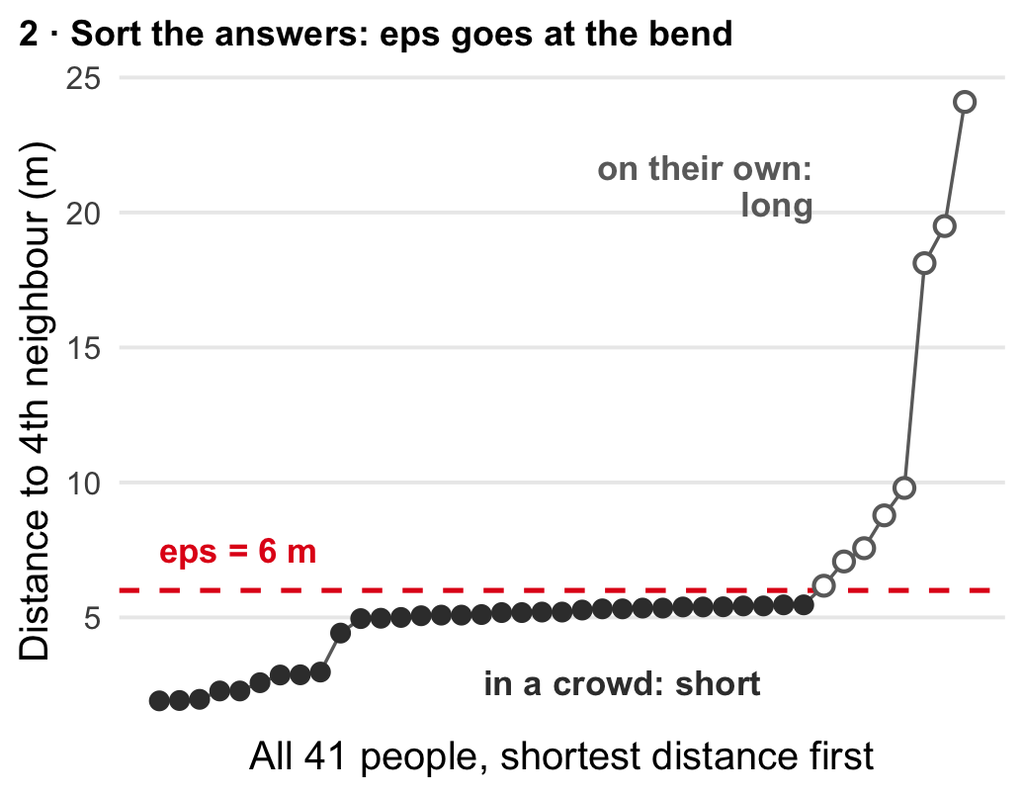

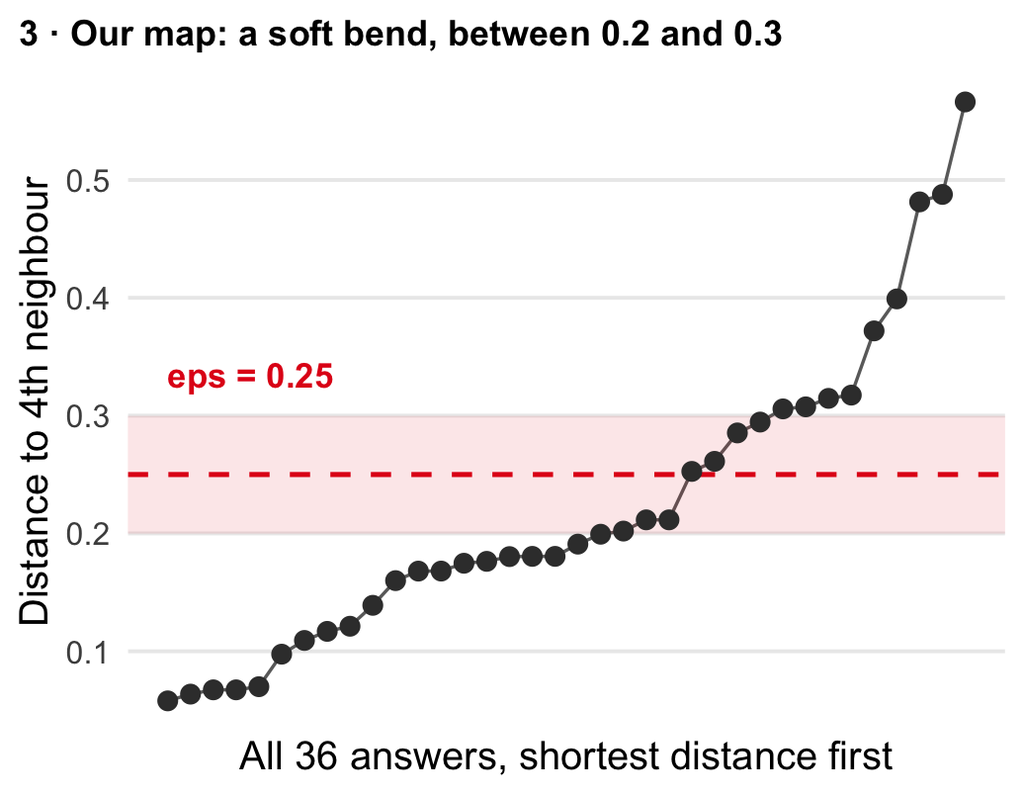

minPts firstthe smallest group you would call a cluster rule of thumb: 2 × columns

Then epshow far is everyone's 4th-nearest neighbour? minPts − 1

Sortcrowds short, loners long: **eps at the bend**

In R`kNNdistplot(x, k = 4)`

No score picks eps for you The bend suggests. A range with the same clusters reassures: 0.2 to 0.3, always 4. **You** judge the meaning.

## k-means or DBSCAN?

WhatI · k-meansII · DBSCANWrap-up

|  | k-means | DBSCAN |
| --- | --- | --- |
| **A group is** | The points nearest one centre | A dense crowd, chained point to point |
| **You choose** | *k*, the number of groups | `eps` and `minPts`: what counts as a crowd |
| **Shapes** | Round blobs of similar size | Any shape |
| **Points far from everything** | Forced into a group, and they pull its centre | Left out as noise (cluster 0) |
| **Random?** | Yes: `set.seed()` and `nstart = 25` | No |
| **Today** | 4 clusters of 9 answers | 4 clusters and 5 noise points at `eps = 0.25` |

Neither is “right” There is no outcome to check against. Trust groups that **survive a change of method and settings**, and that you can name.

Clustering always answers Give k-means random dots and it still returns k groups. Finding clusters is not evidence that groups exist.

## Summary

WhatI · k-meansII · DBSCANWrap-up

**1****Clustering** adds a group column that nobody gave you, using only distances between rows. There is no accuracy: you judge the groups by whether they are tight, stable and nameable

**2****k-means** is the carts in the park: assign everyone to the nearest centre, move each centre to the mean, repeat. You choose *k* with the **elbow** (total squared distance) and the **silhouette** (is each point clearly in its group?). In code: `kmeans(x, centers = k, nstart = 25)`, `$cluster`, `$tot.withinss`, `silhouette()`

**3****DBSCAN** is the festival field: core points have `minPts` neighbours within `eps`, clusters grow from core to core, and whoever is left is **noise**. In code: `dbscan(x, eps = 0.25, minPts = 5)`, `$cluster`, with 0 for noise

**Question:** DBSCAN called both death-penalty answers noise; k-means put them into groups. Which would you report, and what would you say about those two answers?

## Further reading

- The completed notebook goes up after class.
- [*An Introduction to Statistical Learning*](https://www.statlearning.com): 12.4 (clustering methods: k-means and hierarchical clustering). Free PDF.
- [The `dbscan` package vignette](https://cran.r-project.org/package=dbscan): the algorithm in pictures, and `kNNdistplot()` for choosing `eps`.
- [`tidyclust`](https://tidyclust.tidymodels.org): k-means in the tidymodels style of Labs 3–5, with `tune_cluster()` for choosing *k*.

## 30 seconds of feedback

[figure not shown]

How was today’s lab? Scan the code, or open forms.gle/i3uobCAaGmkzf1ns7. It takes 30 seconds and changes what next week looks like.